# Workflow for making recommendations

Thomas MM.; Tom A.

2/3/2021

We’re going to run through the process of making recommendations to users based on their location. There are few things that need working out, including the function names and how to incorporate the outputs from multiple different models for each species. Currently, this only works on random forest models for a subset of species that I could easily download. This markdown document will be updated as and when the functions get updated. The general proces will be as follows:

1. Load in data

This will change depending on how the models are stored etc.

2. Crop all species to a location, main function = filter_distance()

Probably need to create a wrapper function to be able to automatically crop the different models for different species

3. Create a metric, function = recommend_metric()

Very simple at the moment, but will be an eventual ‘DECIDE score’ as Michael put it.

5. Get a summed rank from the ranks of all individual species, function = recommend_agg_rank()

Very simple function to get the sum of ranks across multiple different species.

# 1. Load in the data

The data are currently stored as .rdata files, not sure how they’ll be stored for the app. So this just reads them in, in turn.

```r
# load in the model outputs for each species in turn
# store them as a list and the species names as a list too
# easier to get the names in the for loop to name the different entries

all_spp <- list()
all_spp_name <- c()

# file list
files_list <- list.files('/data/notebooks/rstudio-constraintlayers/Data/raw_data/subset_species_ranfor_29_01_21/',
                         full.names = T)

for(i in 1:length(files_list)){

  # load
  load(files_list[i])

  # store sdm output file
  all_spp[[i]] <- all_mods

  # store names
  all_spp_name[i] <- as.character(all_mods[[1]]$sdm_output$Species)

}

# name the list the names of each species
names(all_spp) <- all_spp_name
```

Just want to check that the files loaded, so will plot some of the predictions.

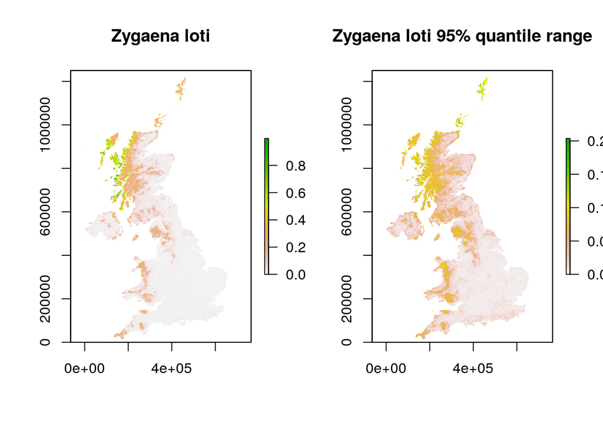

```r
# plot Zygaena loti
par(mfrow = c(1,2))
plot(all_spp[[7]]$rf$sdm_output$Predictions, main = all_spp[[7]]$rf$sdm_output$Species)
plot(all_spp[[7]]$rf$quantile_range, main = paste(all_spp[[7]]$rf$sdm_output$Species, '95% quantile range'))
```

```r
par(mfrow = c(1,1))
```

# 2. Crop all species to a location

Going to crop the rasters to 2000m around Wallingford. This is currently a for loop, but would be easy to change into a wrapper function for it to look a bit nicer. The input variables would be location, distance, a list of species, and the prediction and error raster layers for each species. Would be a lapply() statement (I think).

All this does is cCrop the prediction layer and the bootstrapped variation layer around Wallingford.

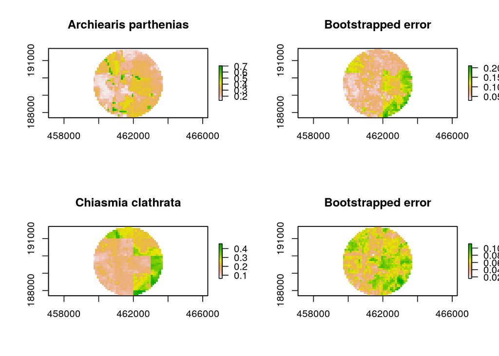

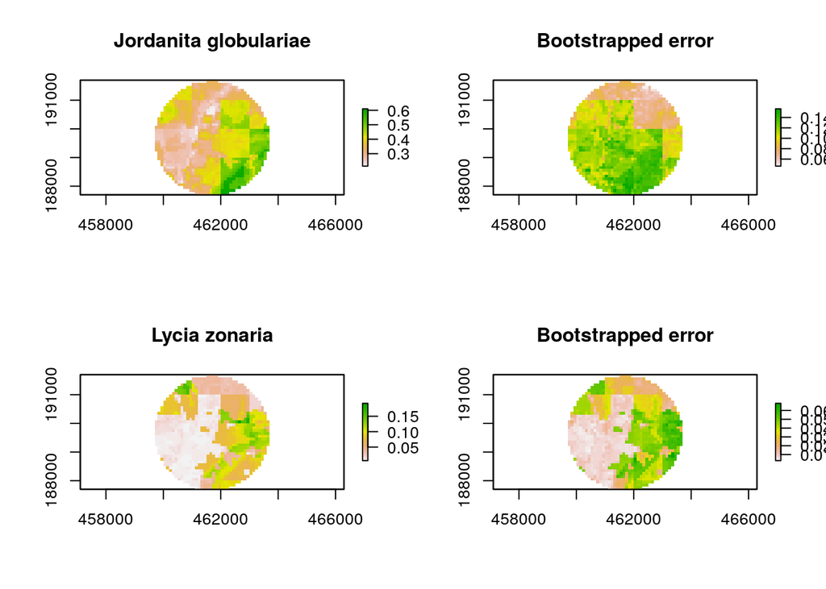

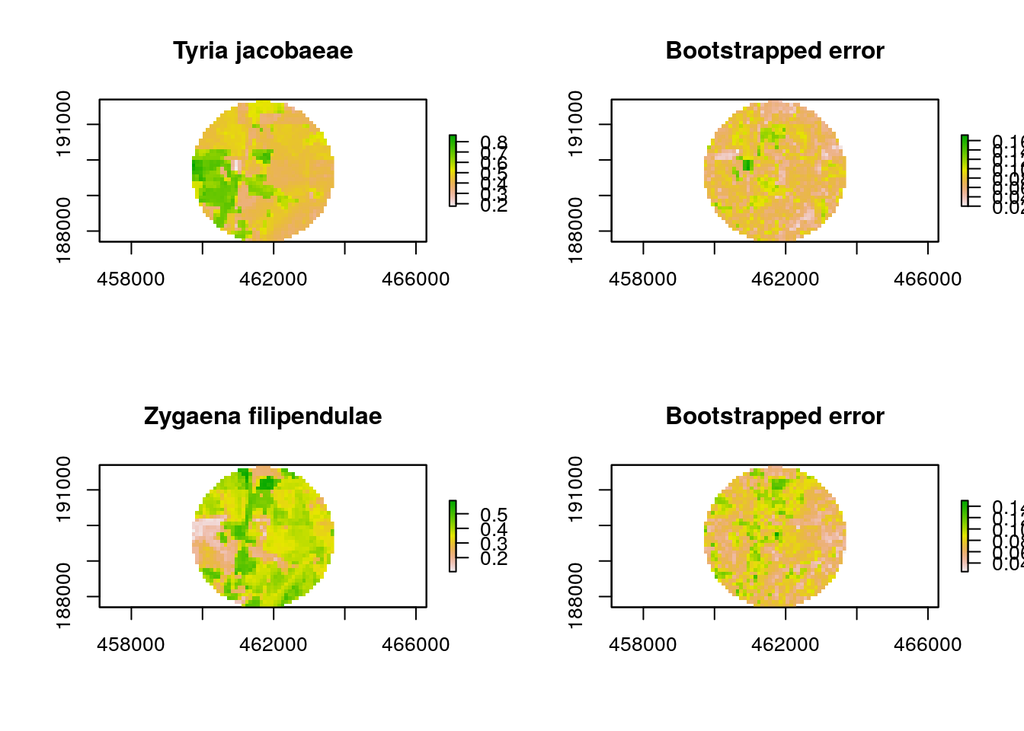

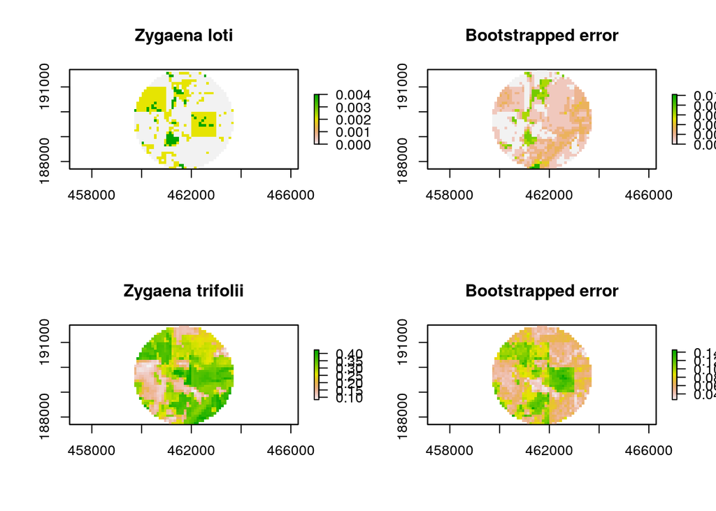

```r
location = c(-1.110557, 51.602436)
distance = 2000

crop_ls_pred <- list()
crop_ls_err <- list()

par(mfrow = c(2,2))

for(j in 1:length(all_spp)) {

  # crop the predictions
  crop_pred <- filter_distance(raster = all_spp[[j]]$rf$sdm_output$Predictions,
                               method = 'buffer',
                               distance = distance,
                               location = location)
  names(crop_pred) <- 'predictions'

  # crop the error
  crop_err <- filter_distance(raster = all_spp[[j]]$rf$quantile_range,
                              method = 'buffer',
                              distance = distance,
                              location = location)
  names(crop_err) <- 'error'

  # plot the predictions and error
  plot(crop_pred, main = all_spp[[j]]$rf$sdm_output$Species)
  plot(crop_err, main = 'Bootstrapped error')

  # store everything in lists
  crop_ls_pred[[j]] <- crop_pred
  crop_ls_err[[j]] <- crop_err

}
```

```r
par(mfrow = c(1,1))
```

Stack the output rasters from the for loop.

```r
# name the different entries in the list as the species they are
names(crop_ls_pred) <- all_spp_name
names(crop_ls_err) <- all_spp_name

# stack the predictions and error
pred <- raster::stack(crop_ls_pred)
err <- raster::stack(crop_ls_err)
# plot(pred)
# plot(err)
```

# 3. Create a metric

Create a metric to decide which cells to visit. Extremely simple addition or multiplication of predictions and error layers for the moment but we can easily add other methods to this function. Michael and WP3 have suggested the idea of a ‘DECIDE score’ which will be based on various SDM layers.

Use the recommend_metric() function get the sum of the prediction and error rasters. It returns a named list so can use multiple metrics if we want to at a later date.

```r
additive_metric <- recommend_metric(prediction_raster = pred,
                                    error_raster = err,
                                    method = 'additive')$additive
additive_metric
```

```
## class       : RasterBrick
## dimensions  : 40, 40, 1600, 8  (nrow, ncol, ncell, nlayers)
## resolution  : 100, 100  (x, y)
## extent      : 459700, 463700, 187700, 191700  (xmin, xmax, ymin, ymax)
## coord. ref. : +proj=tmerc +lat_0=49 +lon_0=-2 +k=0.9996012717 +x_0=400000 +y_0=-100000 +ellps=airy +units=m +no_defs
## data source : in memory
## names       : Archiearis.parthenias, Chiasmia.clathrata, Jordanita.globulariae, Lycia.zonaria, Tyria.jacobaeae, Zygaena.filipendulae, Zygaena.loti, Zygaena.trifolii
## min values  :                0.1713,             0.1326,                0.3052,        0.0111,          0.3401,               0.1747,       0.0000,           0.1241
## max values  :                0.8319,             0.5510,                0.7431,        0.2416,          0.9550,               0.6960,       0.0133,           0.5517
```

# 4. Get the rank of cells to be visited

Get the rank of cells across all species using the recommend_rank() function. Has two options, ‘additive’ which sums the predictions and error raster for each species together and then ranks them according to the highest values. Returns a raster stack of the original metric and the ranking of the cells. And another, ‘species_rank’, which ranks all the species separately and returns a raster stack of the original metric and the ranking of the cells for each species.

## Additive

The code throws a warning about no non-missing arguments when run in the function below, but I can’t recreate it in the function file itself. it only has this warning in the R Markdown document, doesn’t even appear if I copy the code to a normal R script. It’s something to do with the raster creation as the warning is multiplied when doing the ‘specis_rank’ side of the function.

**This is point 1 in the Teams document**

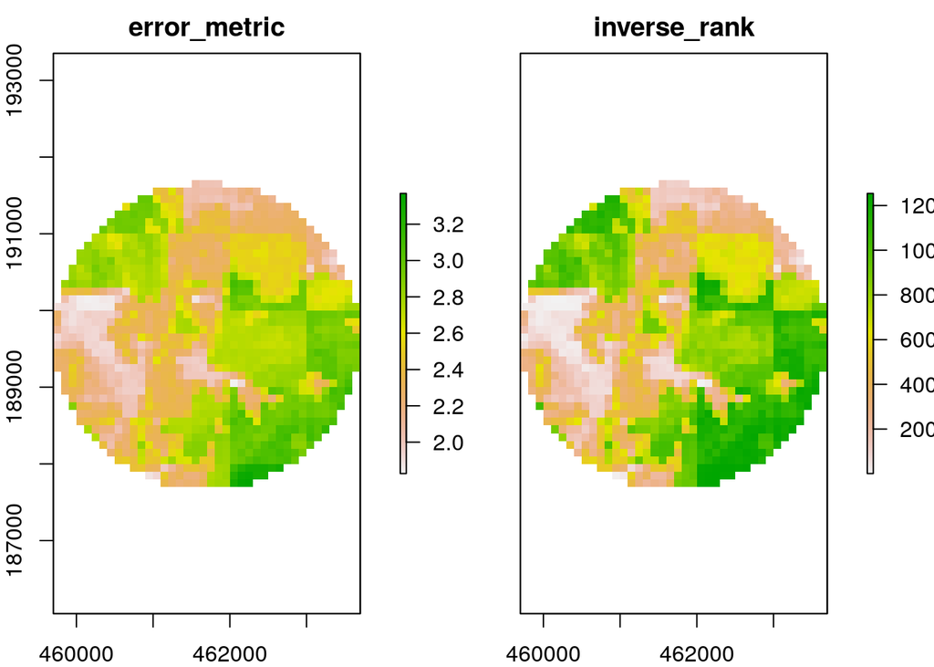

```r
# aggregated rank across all species output = 2 rasters, original metric and inverse rank of cells metric
agg_rank <- recommend_rank(predict_err_raster = additive_metric,
                           method = 'additive')
plot(agg_rank)
```

## ‘species_rank’ method

Get the rank of cells for each species separately and plot one example species, *Archiearis.parthenias*.

**This is point 2 in the Teams document**

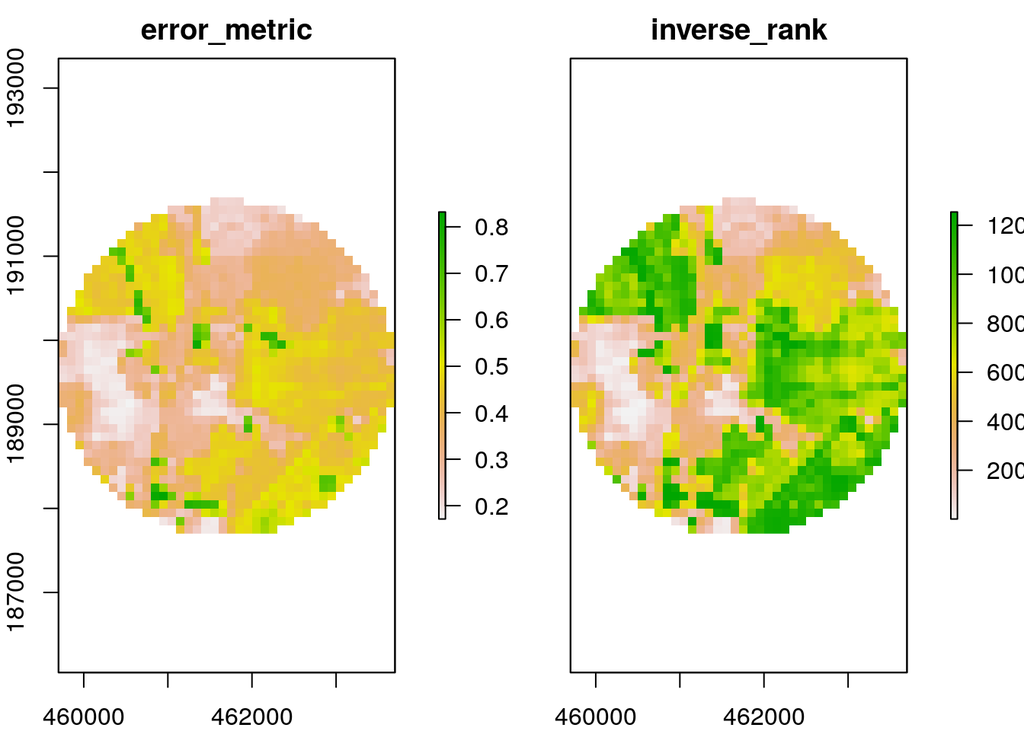

```r
# rank for each species output = 2 rasters for each species, original metric and inverse rank of cells metric
species_rank <- recommend_rank(additive_metric,
                                    method = 'species_rank')

plot(species_rank$Archiearis.parthenias)
```

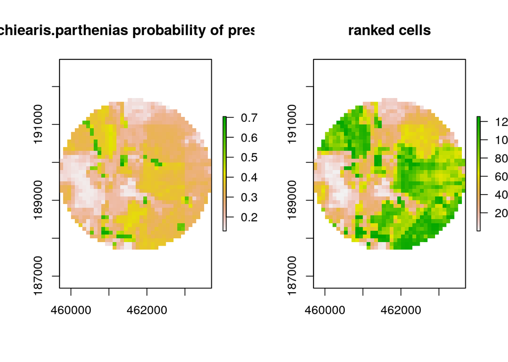

```r
par(mfrow = c(1, 2))
plot(pred$Archiearis.parthenias, main = paste(names(pred[[1]]), 'probability of presence'))
plot(species_rank$Archiearis.parthenias[[2]], main = 'ranked cells')
```

```r
par(mfrow = c(1, 1))
```

# 5. Sum the ranks of all the seperate species

After the method to get the ranks of each species separately, another function to sum the rank layer for each species. This looks different to the ranks generated by first adding all the species together as that method will favour species that have a higher probability of presence in the area of interest. Summing the ranks of each species will put an equal weight on all species, regardless of their probability of presence in the area of interest. This might not make sense in some cases. For example, *Zygaena loti* has an extremely low probability of presence in the area around Wallingford, but in the second method its cells will ‘equal’ to those of other species.

**This is point 3 in the Teams document**

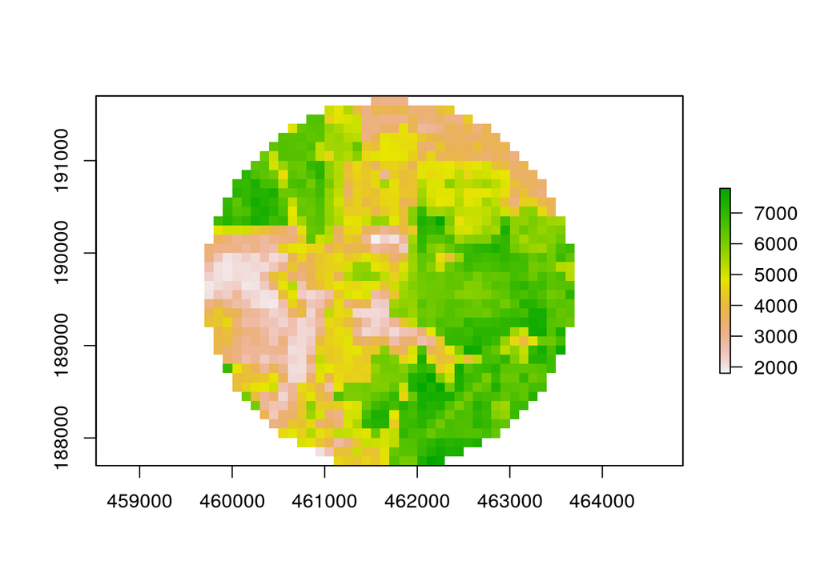

```r
summed_rank_all_spp <- recommend_agg_rank(species_rank)
plot(summed_rank_all_spp)
```

# Further steps

Using the output of each species separately, we could investigate differences between species in the probability and error distributions within the area of interest. This could be useful to identify species that we are particularly uncertain about in a given area/those which are particularly likely to occur - This could be a set of ‘single species recommendations’, (‘recommend_species()’ maybe?).

After this point in the recommend proces we could then get the bridleways/greenspaces etc. using the other functions and then combine them into a single output. for display.